# Campaign Manager Add-on

- Inspect reviewers: View all the candidates that can work on the task, send them an email or reassign the task to one of the candidates.
- Reassign the task: Re-assign the task to another identity. By doing so, the task is automatically assigned to the selected person and this new reviewer is automatically added to the candidate list.

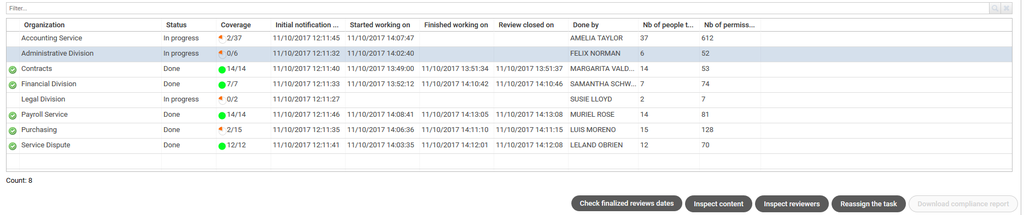

Options for on-going tasks

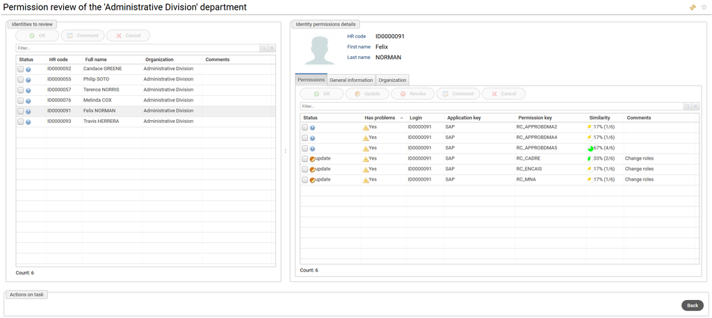

Inspect content

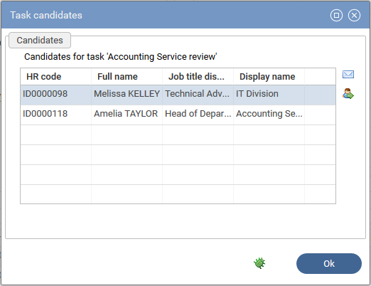

Inspect reviewers

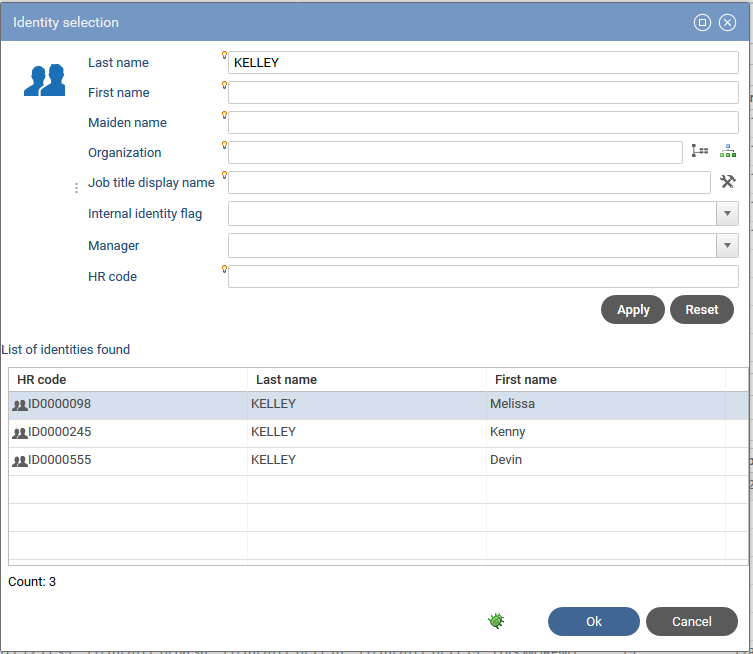

Reassign the task popup

Once the campaign has been done, this means all the tasks have been completed by each actor, you are able from the main page of the campaign manager to directly download the compliance report, by clicking on the “Download compliance report” button in the “campaign instances” part on the bottom right of the main page.

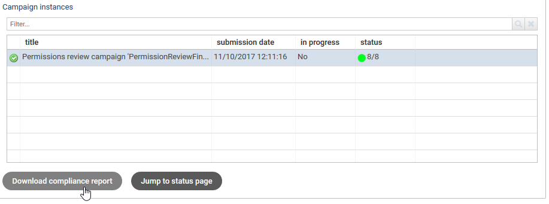

Campaign instances: download compliance report

[figure not shown]

Compliance report of a permissions review campaign

### Delete a campaign

You can delete a campaign only if no instance is active and the campaign is disabled

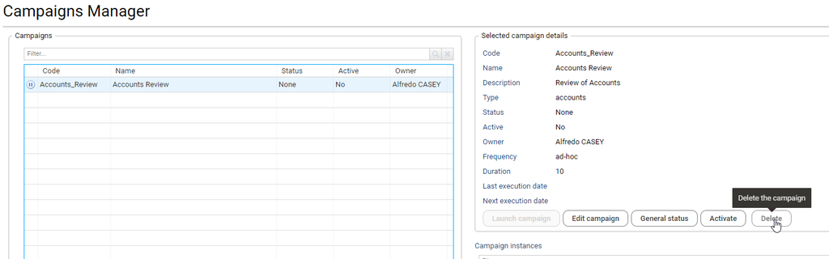

Delete a campaign

You should proceed with caution, this action will delete the flowing elements:

- Campaign definition and all its sub elements
- Compliance reports
- All launched instances
- All associated tickets

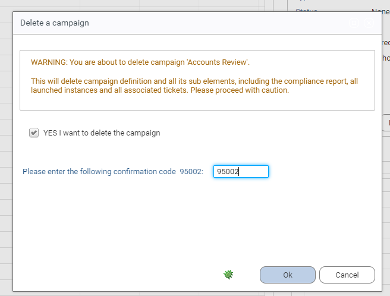

Delete a campaign

**Important:** If you have remediation related to a deleted campaign, links with the reviewed elements will be lost.

**Important:** Deleting big campaigns can take several minutes and may cause performance issues in the portal..

© 1995-2023 [Radiant Logic](https://developer.radiantlogic.com/)